# Heat Transfer and the Second Law of Thermodynamics — Student Notes

**Unit: Thermal Energy & Conservation — Lesson 02** Name: _______________________ Date: __________ Period: ____

## Learning Targets

By the end of today’s 42 minutes I can:

- Describe how **heat** flows from a hotter object to a cooler one until **thermal equilibrium**.
- Identify conduction, convection, and radiation as the three modes of heat transfer.
- State the **second law of thermodynamics** in my own words.

## Key Vocabulary

- **heat** — _______________________________________________
- **thermal equilibrium** — _______________________________________________
- **second law of thermodynamics** — _______________________________________________

## Guided Notes

**Big idea:** When two objects at different temperatures touch, thermal energy flows from the __________ object to the __________ object. It never flows the other way on its own.

- The energy moving because of a temperature difference is called __________.
- The flow continues until both objects reach the __________ temperature — this is __________.
- At equilibrium there is no __________ flow of energy (particles still move, but energy is spread evenly).

**Three ways thermal energy transfers:**

- **Conduction** — energy passes by __________ (particle to particle), e.g. a spoon handle warming.
- **Convection** — a moving __________ (liquid or gas) carries the energy, e.g. warm water rising.
- **Radiation** — energy travels as __________ waves and needs no medium, e.g. warmth from the Sun.

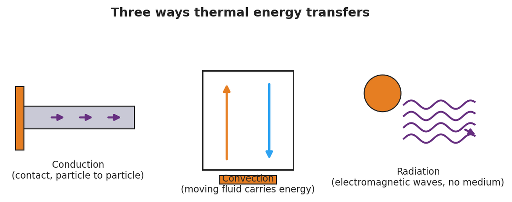

Conduction, convection, radiation

**Second law of thermodynamics:** In a __________ system, thermal energy spontaneously spreads to a more __________ distribution.

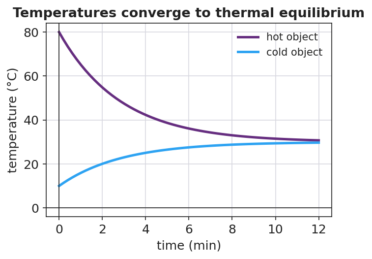

Two temperatures converging to equilibrium

## Worked Example

**Problem.** A hot rock at 80 °C is placed in a sealed, insulated box with cool water at 10 °C. Describe what happens over time.

**Solution.** 1. Thermal energy flows from the __________ rock to the __________ water (hot → cold). 2. The rock’s temperature __________ and the water’s temperature __________. 3. They keep changing until both reach the __________ temperature → **thermal equilibrium**. 4. The energy that was concentrated in the rock is now spread more __________ across the system — the **second law** in action.

## Summary

Finish the sentence (Because / But / So):

> Thermal energy flows from the hot object to the cold object because __________________________________________, but __________________________________________, so __________________________________________.